# Exposure to Generative AI Across Educational Fields in the EU

Andrea Blasco[^1]

This version: 2025-11-07

# 1 Introduction

The rapid development and deployment of artificial intelligence (AI) is expected to reshape labor markets by changing the demand for specific skills and altering the composition of occupational tasks. Previous research has primarily focused on AI exposure at the occupational level (Felten, Raj, and Seamans 2021; Tolan et al. 2021; Felten, Raj, and Seamans 2023; Gmyrek et al. 2025), but less is known about how these effects aggregate across educational fields, particularly among highly educated workers. Are professions carried out by STEM graduates, such as engineers or computer scientists, more exposed to generative AI transformations than those of students graduating from non-STEM schools? Understanding field-specific exposure to AI is critical for anticipating labor market shifts, informing education policy, and guiding workforce planning.

This study aims to quantify the exposure of high-education fields (ISCED 5 - 8) to AI across the EU27 by linking standardised occupational AI exposure scores (Gmyrek et al. 2025) to employment distributions within educational fields from the European Skills and Jobs Survey (Cedefop 2021). The analysis provides a comparative ranking of educational domains according to their relative AI exposure.

Timmerman (2025) explores how generative AI influences postsecondary education and their students in the United States. It finds that college majors are impacted differently, with STEM-related field having higher exposure than non-STEM ons. This is consisetn with (Bick 2024) early study on adoption of gen AI at work; and Mohnen and lee 2024 on the demand for AI skills increased from math et al.

Timmerman (2025) also finds that hispanics are more impacted and institutions most affected are those Liberal Arts.

Grosz (2022) shows that postsecondary programs respond to market shifts.

# 2 Data and Methods

## 2.1 Generative AI Occupational Exposure Index

We used the International Labour Organisation (ILO)’s global exposure to generative AI index (Gmyrek et al. 2025). This uses task descriptions from 4-digit International Standard Classifciation of Occupations (ISCO-08) to estimate task-level occupational exposure. Measures of task-level occupational exposure are obtained by combining GPT-4 models and human annotations. Specifically, Gmyrek et al. (2025) surveyed 1640 people on 30 000 job-related tasks from the Poland’s national 6-digit classification of occupations. It then combined survey results with automatic annotations obtained by GPT-4 models.

This approach to measure generative AI occupational exposure draws from pineering work by Felten, Raj, and Seamans (2021) and Eloundou et al. (2024), which is now established as the most common method.

## 2.2 European Skills and Jobs Survey (ESJS)

We matched the occupational exposure with survey data from occupations for highly skilled individuals obtained from the ESJS, the second wave carried out in 2021 (Cedefop 2021). This survey includes information from 46 000 adult employees from 35 countries, including all the EU Member States. The survey includes questions on sociodemographics, job characteristics, and intial education, including the highest education degree achieve and, when applies, the field major. Jobs are then manually coded into ISCO-08 descriptions, allowing us to match with the ILO’s global generative AI occupational exposure index described above. Academic fields are coded into standard ISCED (narrow) codes.

## 2.3 Data Analysis

Following the approach of Timmerman (2025), we implemented a post-stratification framework to estimate occupational generative AI exposure across academic fields. First, we used OLS regression to estimate the mean generative AI score for all professions at the ISCO-08 level 2. Next, leveraging data from ESJS, we calculated the distribution of employees within each profession by highest educational attainment and corresponding field of study (e.g., the share of computer science graduates within a given profession). We then combined these shares with the OLS-estimated scores to predict the occupational generative AI score conditional on educational background and field. Finally, we aggregated the predicted scores by differnet categories (e.g., country, academic field) to conduct cross-national and field-level analyses.

# 3 Results

Figure 3.1 illustrates the generative AI exposures z-scored by country for broad fields of education (ISCED-F level 1).

In most countries, fields like *Business & Law* or *Social sciences, journalism, and information*, tend to have the highest relative generative AI exposure, meaning these areas are more gen-AI-exposed compared to other fields within the same country. *Arts & humanities* also show high relative exposure in several countries, particularly in Northern and Western Europe (e.g., Norway, Belgium, Austria), while fields like *Health & welfare*, *Agriculture*, and *Services* are consistently lower within each country, indicating they are less exposed to generative AI relative to other domestic fields. *Natural sciences, mathematics and statistics* show mixed patterns, sometimes moderately high (e.g., Poland) but other times below average (e.g., Finland, Germany, Czechia). Fields such as *Engineering and manufacturing* or *Education* are often below average. Overall, this shows a consistent pattern where knowledge-intensive, analytical, and social-oriented fields dominate AI exposure within countries, while practical, service-oriented, and traditionally manual sectors are less affected, even if the absolute level of AI adoption varies across countries.

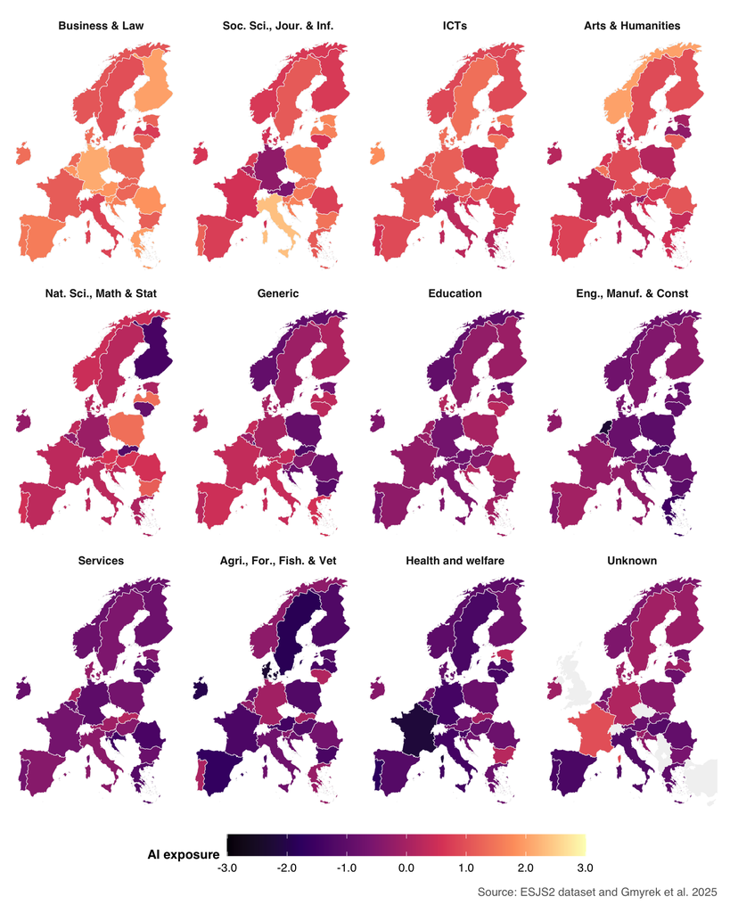

Figure 3.1: Generative AI exposure across academic fields in the EU

Following the analysis at the macro level, we examine differences in the z-scored exposured across narrowly defined fields of education (ISCED-F level 2), providing a more detailed view of the exposure.

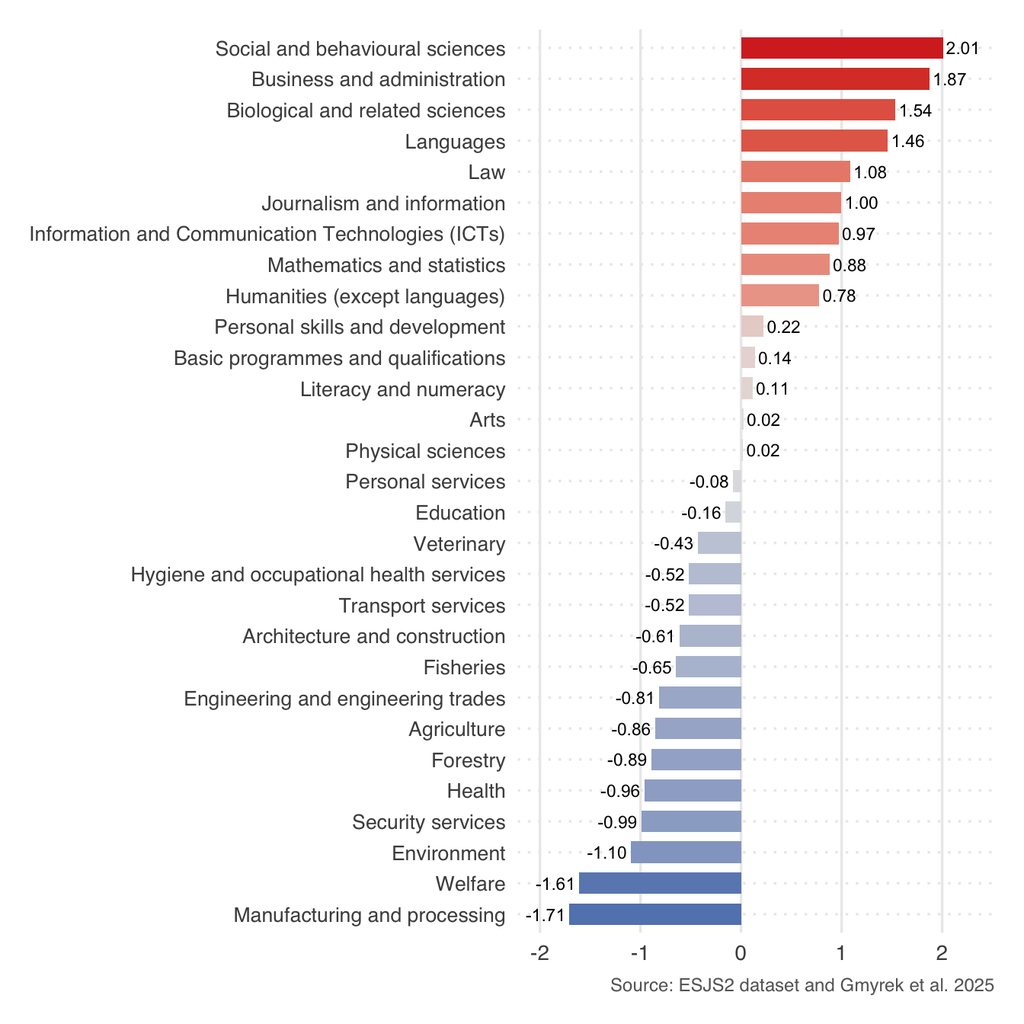

Figure 3.2: Generative AI occupational exposure across academic fields in the EU 27

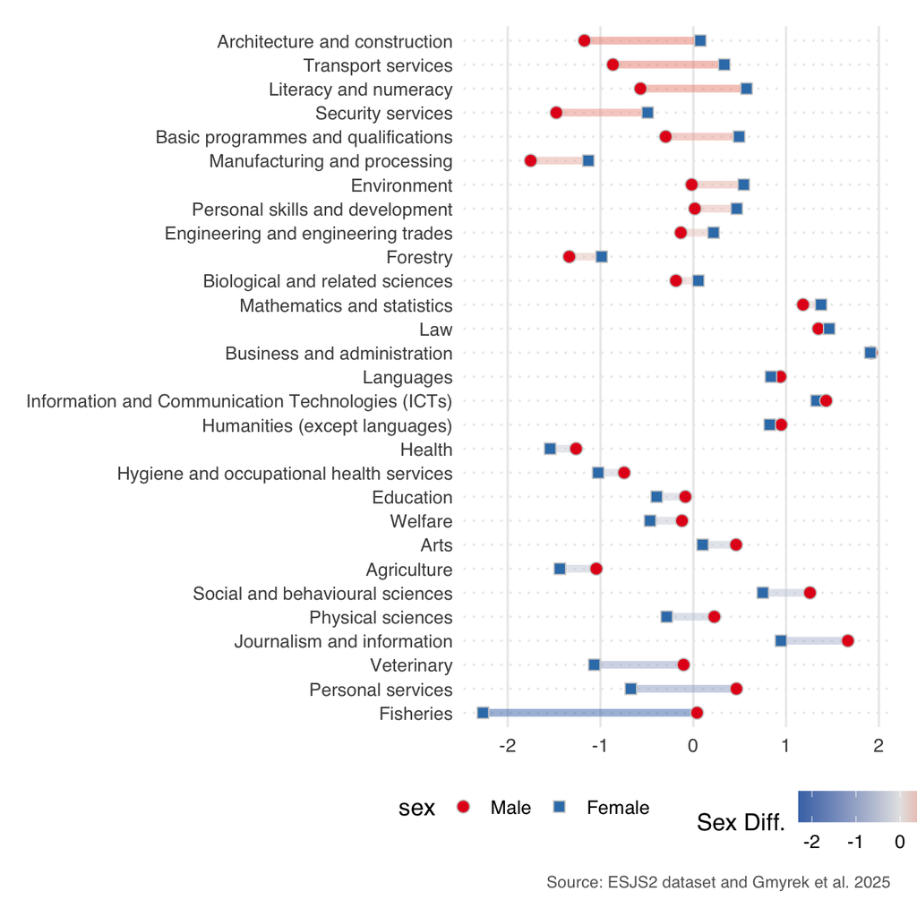

Figure 3.3: Generative AI exposure across genders in the EU 27

# 4 Discussion

# 5 References

# Appendix

Cedefop. 2021. *Cedefop Second European Skills and Jobs Survey (1st Edition) [Data Set]*. [Https://www.cedefop.europa.eu/en/projects/european-skills-and-jobs-survey-esjs](https://www.cedefop.europa.eu/en/projects/european-skills-and-jobs-survey-esjs).

Conzelmann, Johnathan G, Steven W Hemelt, Brad Hershbein, Shawn M Martin, Andrew Simon, and Kevin M Stange. 2023. *Skills, Majors, and Jobs: Does Higher Education Respond?* National Bureau of Economic Research.

Eloundou, Tyna, Sam Manning, Pamela Mishkin, and Daniel Rock. 2024. “GPTs Are GPTs: Labor Market Impact Potential of LLMs.” *Science* 384 (6702): 1306–1308.

Felten, Edward W, Manav Raj, and Robert Seamans. 2023. “Occupational Heterogeneity in Exposure to Generative AI.” *Available at SSRN 4414065*, 2023.

Felten, Edward, Manav Raj, and Robert Seamans. 2021. “Occupational, Industry, and Geographic Exposure to Artificial Intelligence: A Novel Dataset and Its Potential Uses.” *Strategic Management Journal* 42 (12): 2195–2217.

Gmyrek, Paweł, Janine Berg, Karol Kamiński, Filip Konopczyński, Agnieszka Ładna, Balint Nafradi, Konrad Rosłaniec, and Marek Troszyński. 2025. *Generative AI and Jobs: A Refined Global Index of Occupational Exposure*. ILO Working Paper.

Grosz, Michel. 2022. “Do Postsecondary Training Programs Respond to Changes in the Labor Market?” *Journal of Human Capital* 16 (4): 461–487.

Timmerman, Jean Xiao. 2025. “Educational Exposure to Generative Artificial Intelligence.” In *FEDS Notes*. Washington: Board of Governors of the Federal Reserve System. https://doi.org/10.17016/2380-7172.3703.

Tolan, Songül, Annarosa Pesole, Fernando Martı́nez-Plumed, Enrique Fernández-Macı́as, José Hernández-Orallo, and Emilia Gómez. 2021. “Measuring the Occupational Impact of AI: Tasks, Cognitive Abilities and AI Benchmarks.” *Journal of Artificial Intelligence Research* 71: 191–236.

[^1]: European Commission, mJoint Research Centre, andrea.blasco@ec.europa.eu